# 2019DecemberHawaii_report

Tim C.

01/15/2020

### Personnel

| collectors |
| --- |
| claytondilks2023@u.northwestern.edu |
| erik.andersen@northwestern.edu |
| gaotian52@gmail.com |

| isolators |
| --- |
| claire.buchanan@northwestern.edu |
| lorainastinson2024@u.northwestern.edu |
| robyn.tanny@northwestern.edu |
| nicoleroberto2018@u.northwestern.edu |
| tcrombie@northwestern.edu |
| erik.andersen@northwestern.edu |
| claytondilks2023@u.northwestern.edu |

### Project Overview

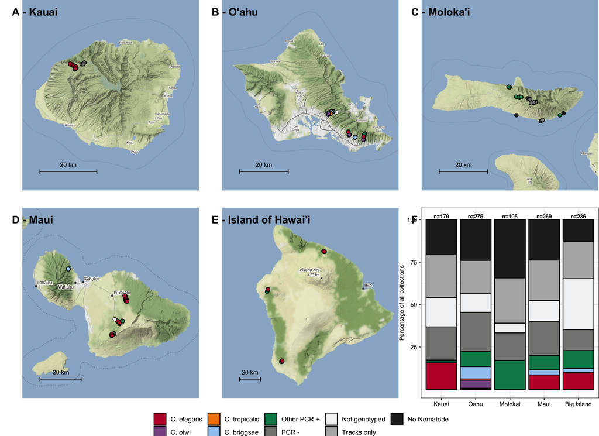

### Collection Report

| collection report | value |
| --- | --- |
| total number of distinct collections | 1065 |
| total number of distinct collections NAs removed | 1064 |
| collections with nematodes | 588 |
| collections with tracks only | 243 |
| collections without nematodes | 230 |
| collection percentage with nematodes | 55.3% |
| collection percentage with tracks only | 22.8% |
| collection percentage with no worms | 21.6% |
| collections with duplicated ids | 0 |
| collections with NA for colleciton id | 6 |
| collections without paired isolation data | 3 |
| collections with location method ‘photo’ | 1061 |
| collections with location method ‘fulcrum’ | 3 |
| collection percentage with loc method ‘photo’ | 99.7% |
| collection percentage with loc method ‘fulcrum’ | 0.3% |
| collections with altitude method ‘geonames’ | 1061 |
| collections with altitude method ‘fulcrum’ | 3 |
| collection percentage with altitude method ‘geonames’ | 99.7% |
| collection percentage with altitude method ‘fulcrum’ | 0.3% |

### Isolation Report

| isolation report | value |
| --- | --- |
| total number of distinct isolations | 2367 |
| total number of distinct isolations NAs removed | 2366 |
| average isolations per collection with worms | 4.01360544217687 |
| isolations with duplicated ids |  |
| isolations without paired collection data | (6 plates) S-11856,S-11693,S-11787,S-11788,S-11789,S-XXXXX |
| Possible new Caenorhabditis sp. isolations | 31 |
| Isolations that need to be resequenced | 28 |
| Auanema freiburgensis | 3 |
| C. briggsae | 136 |
| C. elegans | 267 |
| C. kamaaina | 1 |
| C. oiwi | 31 |
| C. plicata | 12 |
| C. sp. 21 | 11 |
| C. tropicalis | 9 |
| Caenorhabditis sp. p LS-2018 | 8 |
| Choriorhabditis cristata | 5 |
| Chryseobacterium indologenes | 1 |
| H. bacteriaphora | 1 |
| Mesorhabditis | 4 |
| Mesorhabditis belari | 2 |
| Mesorhabditis sp. | 10 |
| No amplification | 2 |
| No signficance | 1 |
| No significance | 8 |
| Not genotyped | 995 |
| O. myriophilus | 19 |
| O. sp | 95 |
| O. sp. | 3 |
| O. sp. AH13 | 6 |
| O. tipulae | 35 |
| PCR - | 677 |
| Rhabditella axei | 6 |
| Troglostrongylus brevior | 1 |
| uncultured soil fungus | 3 |

### Duplications Report

1 c_label(s) duplicated in nematode_field_sampling.csv

| fulcrum_id | created_at | updated_at | created_by | updated_by | system_created_at | system_updated_at | version | status | project | assigned_to | latitude | longitude | geometry | sample_photo | sample_photo_caption | sample_photo_url | substrate | substrate_other | substrate_notes | landscape | sky_view | gridsect | gridsect_index | grid_sect_direction | gridsect_radius | substrate_temperature | ambient_temperature_c | ambient_humidity | c_label | … |
| --- | --- | --- | --- | --- | --- | --- | --- | --- | --- | --- | --- | --- | --- | --- | --- | --- | --- | --- | --- | --- | --- | --- | --- | --- | --- | --- | --- | --- | --- | --- |
| c5f5e582-0493-486c-a150-dd5c0dbb98a9 | 2019-12-11 21:32:43 UTC | 2019-12-11 21:33:40 UTC | gaotian52@gmail.com | gaotian52@gmail.com | 2019-12-12 01:13:24 UTC | 2019-12-12 01:13:24 UTC | 1 | NA | 2019DecemberHawaii | NA | 20.03876 | -155.4400 | POINT (-155.439979322399 20.0387621345185) | 950dad65-f56a-4f0e-8bba-95216eb4a091 | NA | https://web.fulcrumapp.com/photos/view?photos=950dad65-f56a-4f0e-8bba-95216eb4a091 | Fruit | NA | NA | Wild forest | Partially Obstructed | no | NA | NA | NA | 21 | 23.1 | 74.1 | C-0871 | … |
| dc90c6f0-3357-43b5-86db-4d7cd66cf0de | 2019-12-12 03:08:15 UTC | 2019-12-12 03:08:37 UTC | claytondilks2023@u.northwestern.edu | claytondilks2023@u.northwestern.edu | 2019-12-12 03:15:42 UTC | 2019-12-12 03:15:42 UTC | 1 | NA | 2019DecemberHawaii | NA | 19.42903 | -155.2377 | POINT (-155.237680659085 19.4290322610295) | fecba88c-1f7f-497e-9b52-6588a62aa1bf,ec470f09-f74d-452b-b5da-884f82a0e728 | , | https://web.fulcrumapp.com/photos/view?photos=fecba88c-1f7f-497e-9b52-6588a62aa1bf%2Cec470f09-f74d-452b-b5da-884f82a0e728 | Fruit | NA | Location at 871 | Wild forest | Partially Obstructed | no | NA | NA | NA | NA | NA | NA | C-0871 | … |

0 isolation id(s) duplicated in nematode_isolation.csv

| fulcrum_id | created_at | updated_at | created_by | updated_by | system_created_at | system_updated_at | version | status | project | assigned_to | latitude | longitude | geometry | c_label | worms_on_sample | approximate_number_of_worms | photos | photos_caption | photos_url | date | time | gps_altitude | gps_horizontal_accuracy | gps_vertical_accuracy | gps_speed | gps_course | distinct_fulcrum_id_count | distinct_c_label_count |
| --- | --- | --- | --- | --- | --- | --- | --- | --- | --- | --- | --- | --- | --- | --- | --- | --- | --- | --- | --- | --- | --- | --- | --- | --- | --- | --- | --- | --- |

0 collection(s) with duplicated isolations in nematode_isolation.csv

| fulcrum_id | created_at | updated_at | created_by | updated_by | system_created_at | system_updated_at | version | status | project | assigned_to | latitude | longitude | geometry | c_label | worms_on_sample | approximate_number_of_worms | photos | photos_caption | photos_url | date | time | gps_altitude | gps_horizontal_accuracy | gps_vertical_accuracy | gps_speed | gps_course | distinct_fulcrum_id_count | distinct_c_label_count |
| --- | --- | --- | --- | --- | --- | --- | --- | --- | --- | --- | --- | --- | --- | --- | --- | --- | --- | --- | --- | --- | --- | --- | --- | --- | --- | --- | --- | --- |

1 s_label(s) duplicated in nematode_isolation_s_labeled_plates.csv

| fulcrum_id | fulcrum_parent_id | fulcrum_record_id | version | latitude | longitude | geometry | created_at | updated_at | created_by | updated_by | s_label | n |
| --- | --- | --- | --- | --- | --- | --- | --- | --- | --- | --- | --- | --- |
| 4eda5a16-e90b-471f-a63a-82191df53bcd | 9a006233-2ca5-4efb-87f5-b079241e274d | 9a006233-2ca5-4efb-87f5-b079241e274d | 1 | 42.05807 | -87.67425 | POINT (-87.67425366350979 42.05807312320762) | 2019-12-16 23:52:15 UTC | 2019-12-16 23:52:21 UTC | claytondilks2023@u.northwestern.edu | claytondilks2023@u.northwestern.edu | S-11690 | 2 |
| 2e995af4-53b0-4ad3-99e3-e2557669e67a | 9a006233-2ca5-4efb-87f5-b079241e274d | 9a006233-2ca5-4efb-87f5-b079241e274d | 1 | 42.05807 | -87.67425 | POINT (-87.67425366350979 42.05807312320762) | 2019-12-16 23:52:29 UTC | 2019-12-16 23:52:33 UTC | claytondilks2023@u.northwestern.edu | claytondilks2023@u.northwestern.edu | S-11690 | 2 |

0 s_label(s) duplicated in genotyping sheet

| s_label | species_id | ITS2_pcr_product | rhabditid_pcr_product | notes | manual_blast_notes | ECA_dirty | ECA_clean | n |
| --- | --- | --- | --- | --- | --- | --- | --- | --- |

These dataframes are filtered to show the duplications in the raw data from fulcrum or the genotyping sheet. If the dataframe are empty there is no duplication.  
**Duplication issue 1:** Duplication in feild sampling comes from collection_id C-0871.  
**Solution:** Remove Gaotian’s instance of C-0871 after extracting collection data from it and applying these data to all  
collections that contained the `Location at 871` flag in the `substrate_notes` column. See lines 503-523 in  
process_fulcrum_data.R script.  
**Duplication issue 2:** Duplicated isolation record for S-11690.  
**Solution:** The extra S-11690 record was removed in Step 5 of process_fulcrum_data.R script.

### Location Review

[interactive chart not shown]

Use this map to manually check latitidue and longitude of collection records.  
*Red points* are located using `fulcrum` lat,long and may need to be corrected.  
*Green points* are located using `photo` lat,long and are usually accurate.

### Target species map

[interactive chart not shown]

### Possible new species map

[interactive chart not shown]

### Concerns as of 20200119

**1.** One collection (C-0882) has a c-label (C-0882) rather than an s-label for isolation_id.  
**2.** One s-label is S-XXXXX? Could this resolve concern 1?  
**3.** Possible new caeno species isolations need to be confirmed.  
**4.** There are 28 isolations that have notes suggesting they need to be resequenced. These include all isolations with notes mentioning redos, ITS2 positive without species_ids, or species_ids as “No significance”, “No amplification”, or “unclutured soil fungus”.